# MSiA 401 HW1

#### 2.10(1) Estimate the price elasticities of all three steaks. Given that chuck is the least expensive cut and porter house is the most expensive cut of beef among these three cuts, are their price elasticities in the expected order?

```r
# read file
steakprices <- read.csv(here::here("steakprices.CSV"))
summary(steakprices)
```

```
##       Year          Month         Chuck.Qty      Chuck.Price
##  Min.   :2001   Min.   : 1.00   Min.   : 76.00   Length:48
##  1st Qu.:2002   1st Qu.: 3.75   1st Qu.: 89.75   Class :character
##  Median :2002   Median : 6.50   Median :105.00   Mode  :character
##  Mean   :2002   Mean   : 6.50   Mean   :108.77
##  3rd Qu.:2003   3rd Qu.: 9.25   3rd Qu.:126.50
##  Max.   :2004   Max.   :12.00   Max.   :184.00
##   PortHse.Qty     PortHse.Price        RibEye.Qty    RibEye.Price
##  Min.   : 25.00   Length:48          Min.   : 63.0   Length:48
##  1st Qu.: 45.00   Class :character   1st Qu.: 90.5   Class :character
##  Median : 64.00   Mode  :character   Median :113.5   Mode  :character
##  Mean   : 72.56                      Mean   :122.0
##  3rd Qu.: 92.00                      3rd Qu.:144.5
##  Max.   :157.00                      Max.   :280.0
```

```r
head(steakprices)
```

```
##   Year Month Chuck.Qty Chuck.Price PortHse.Qty PortHse.Price RibEye.Qty
## 1 2001     1       120      $2.28           53        $6.04          74
## 2 2001     2        76      $2.61           81        $5.37          79
## 3 2001     3       102      $2.12           60        $5.74          71
## 4 2001     4       106      $2.41           65        $6.93         112
## 5 2001     5        87      $2.39           92        $5.95         113
## 6 2001     6        94      $2.11          157        $5.24          89
##   RibEye.Price
## 1       $7.02
## 2       $7.16
## 3       $7.33
## 4       $7.38
## 5       $6.47
## 6       $7.14
```

```r
# clean file
steakprices[, c("Chuck.Price", "PortHse.Price", "RibEye.Price")] <- lapply(steakprices[, c("Chuck.Price", "PortHse.Price", "RibEye.Price")], function(x) as.numeric(gsub("\\$", "", x)))

head(steakprices)
```

```
##   Year Month Chuck.Qty Chuck.Price PortHse.Qty PortHse.Price RibEye.Qty
## 1 2001     1       120        2.28          53          6.04         74
## 2 2001     2        76        2.61          81          5.37         79
## 3 2001     3       102        2.12          60          5.74         71
## 4 2001     4       106        2.41          65          6.93        112
## 5 2001     5        87        2.39          92          5.95        113
## 6 2001     6        94        2.11         157          5.24         89
##   RibEye.Price
## 1         7.02
## 2         7.16
## 3         7.33
## 4         7.38
## 5         6.47
## 6         7.14
```

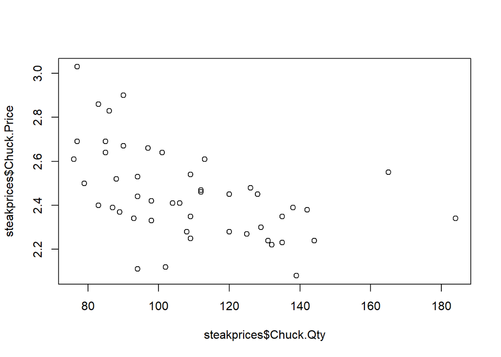

```r
# plot price-quantity relationships
plot_chuck <- plot(steakprices$Chuck.Qty, steakprices$Chuck.Price)
```

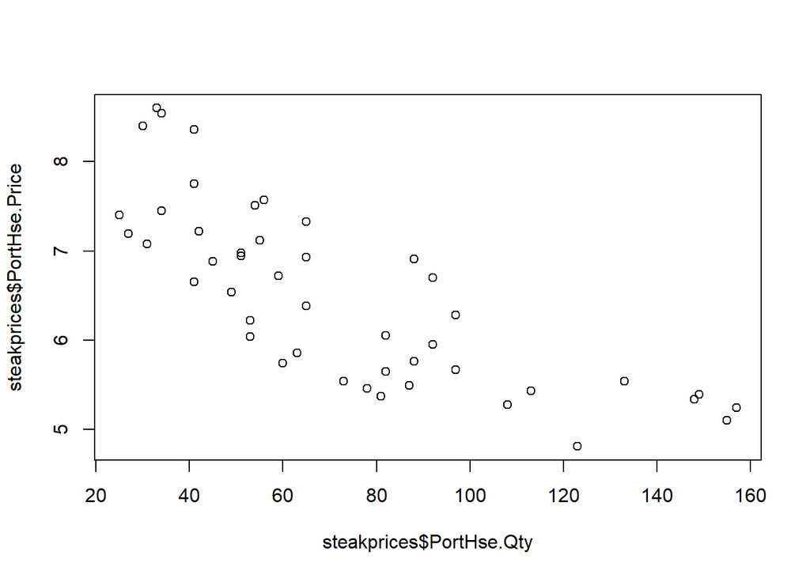

```r
plot_porthse <- plot(steakprices$PortHse.Qty, steakprices$PortHse.Price)
```

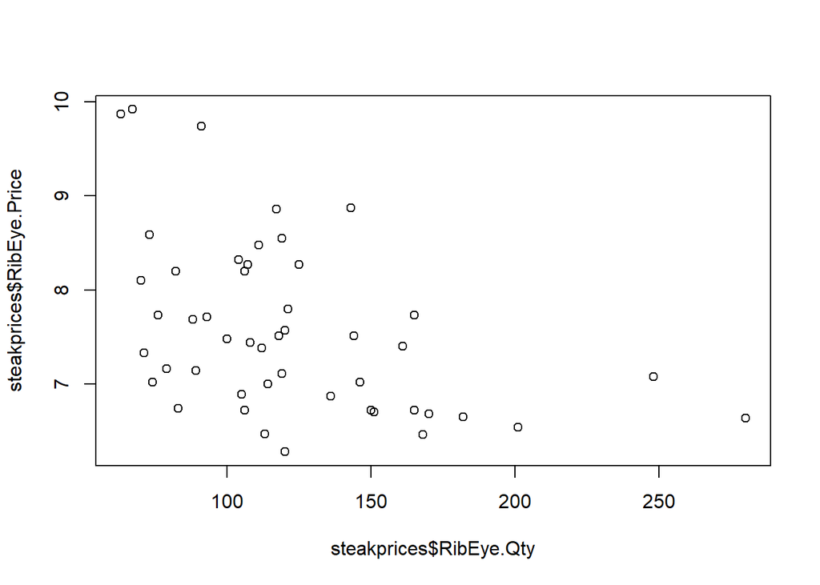

```r
plot_ribeye <- plot(steakprices$RibEye.Qty, steakprices$RibEye.Price)
```

```r
# apply log transformation, find LS lines
line_chuck <- lm(log(Chuck.Qty) ~ log(Chuck.Price), steakprices)
line_porthse <- lm(log(PortHse.Qty) ~ log(PortHse.Price), steakprices)
line_ribeye <- lm(log(RibEye.Qty) ~ log(RibEye.Price), steakprices)

# plot LS lines
summary(line_chuck)
```

```
##
## Call:
## lm(formula = log(Chuck.Qty) ~ log(Chuck.Price), data = steakprices)
##
## Residuals:
##      Min       1Q   Median       3Q      Max
## -0.32463 -0.12036 -0.01714  0.09430  0.49725
##
## Coefficients:
##                  Estimate Std. Error t value Pr(>|t|)
## (Intercept)        5.8899     0.2871  20.513  < 2e-16 ***
## log(Chuck.Price)  -1.3687     0.3199  -4.278 9.44e-05 ***
## ---
## Signif. codes:  0 '***' 0.001 '**' 0.01 '*' 0.05 '.' 0.1 ' ' 1
##
## Residual standard error: 0.1812 on 46 degrees of freedom
## Multiple R-squared:  0.2846, Adjusted R-squared:  0.2691
## F-statistic:  18.3 on 1 and 46 DF,  p-value: 9.441e-05
```

```r
summary(line_porthse)
```

```
##
## Call:
## lm(formula = log(PortHse.Qty) ~ log(PortHse.Price), data = steakprices)
##
## Residuals:
##      Min       1Q   Median       3Q      Max
## -0.57655 -0.23544  0.00317  0.23511  0.49991
##
## Coefficients:
##                    Estimate Std. Error t value Pr(>|t|)
## (Intercept)          9.1123     0.5136  17.742  < 2e-16 ***
## log(PortHse.Price)  -2.6565     0.2752  -9.654 1.23e-12 ***
## ---
## Signif. codes:  0 '***' 0.001 '**' 0.01 '*' 0.05 '.' 0.1 ' ' 1
##
## Residual standard error: 0.283 on 46 degrees of freedom
## Multiple R-squared:  0.6695, Adjusted R-squared:  0.6624
## F-statistic:  93.2 on 1 and 46 DF,  p-value: 1.233e-12
```

```r
summary(line_ribeye)
```

```
##
## Call:
## lm(formula = log(RibEye.Qty) ~ log(RibEye.Price), data = steakprices)
##
## Residuals:
##      Min       1Q   Median       3Q      Max
## -0.54075 -0.21801  0.03995  0.20328  0.70950
##
## Coefficients:
##                   Estimate Std. Error t value Pr(>|t|)
## (Intercept)         7.6627     0.7537  10.167 2.39e-13 ***
## log(RibEye.Price)  -1.4460     0.3731  -3.876 0.000335 ***
## ---
## Signif. codes:  0 '***' 0.001 '**' 0.01 '*' 0.05 '.' 0.1 ' ' 1
##
## Residual standard error: 0.2943 on 46 degrees of freedom
## Multiple R-squared:  0.2462, Adjusted R-squared:  0.2298
## F-statistic: 15.02 on 1 and 46 DF,  p-value: 0.0003352
```

```r
# estimate price elasticities
pe_chuck <- coef(line_chuck)[2]
pe_porthse <- coef(line_porthse)[2]
pe_ribeye <- coef(line_ribeye)[2]

# The price elasticities of chuck, rib eye, and porter house are -1.37, -1.45, and -2.66 respectively. Thus, the order of the elasticities is indeed the same as the order of expensiveness. We would expect the most expensive cut to be the most elastic and vice versa.
```

#### 2.10(2) Estimate how much the demand will change if the price is increased by 10% for each cut.

```r
demand_chuck <- 10 * pe_chuck

demand_porthse <- 10 * pe_porthse

demand_ribeye <- 10 * pe_ribeye

demand_chuck
```

```
## log(Chuck.Price)
##        -13.68665
```

```r
demand_porthse
```

```
## log(PortHse.Price)
##          -26.56487
```

```r
demand_ribeye
```

```
## log(RibEye.Price)
##         -14.46004
```

```r
# Demand for chuck will drop by 13.7%. Demand for porter house will drop by 26.6%. Demand for ribeye will drop by 14.5%.
```

#### 2.11(1) Make scatter plots of the number of deaths due to each type of cancer versus cigarettes smoked to see what types of relationships (linear, nonlinear) exist and if there are any outliers.

```r
# read file
cancer <- read.csv("Cancer Data.csv")
summary(cancer)
```

```
##     STATE             CIG.SMOKED       BLADDER           LUNG
##  Length:44          Min.   :14.00   Min.   :2.860   Min.   :12.01
##  Class :character   1st Qu.:21.23   1st Qu.:3.208   1st Qu.:16.44
##  Mode  :character   Median :23.77   Median :4.065   Median :20.32
##                     Mean   :24.91   Mean   :4.121   Mean   :19.65
##                     3rd Qu.:28.10   3rd Qu.:4.782   3rd Qu.:22.81
##                     Max.   :42.40   Max.   :6.540   Max.   :27.27
##      KIDNEY         LEUKEMIA
##  Min.   :1.590   Min.   :4.900
##  1st Qu.:2.458   1st Qu.:6.532
##  Median :2.845   Median :6.860
##  Mean   :2.795   Mean   :6.830
##  3rd Qu.:3.112   3rd Qu.:7.207
##  Max.   :4.320   Max.   :8.280
```

```r
head(cancer)
```

```
##   STATE CIG.SMOKED BLADDER  LUNG KIDNEY LEUKEMIA
## 1    AK      30.34    3.46 25.88   4.32     4.90
## 2    AL      18.20    2.90 17.05   1.59     6.15
## 3    AZ      25.82    3.52 19.80   2.75     6.61
## 4    AR      18.24    2.99 15.98   2.02     6.94
## 5    CA      28.60    4.46 22.07   2.66     7.06
## 6    CT      31.10    5.11 22.83   3.35     7.20
```

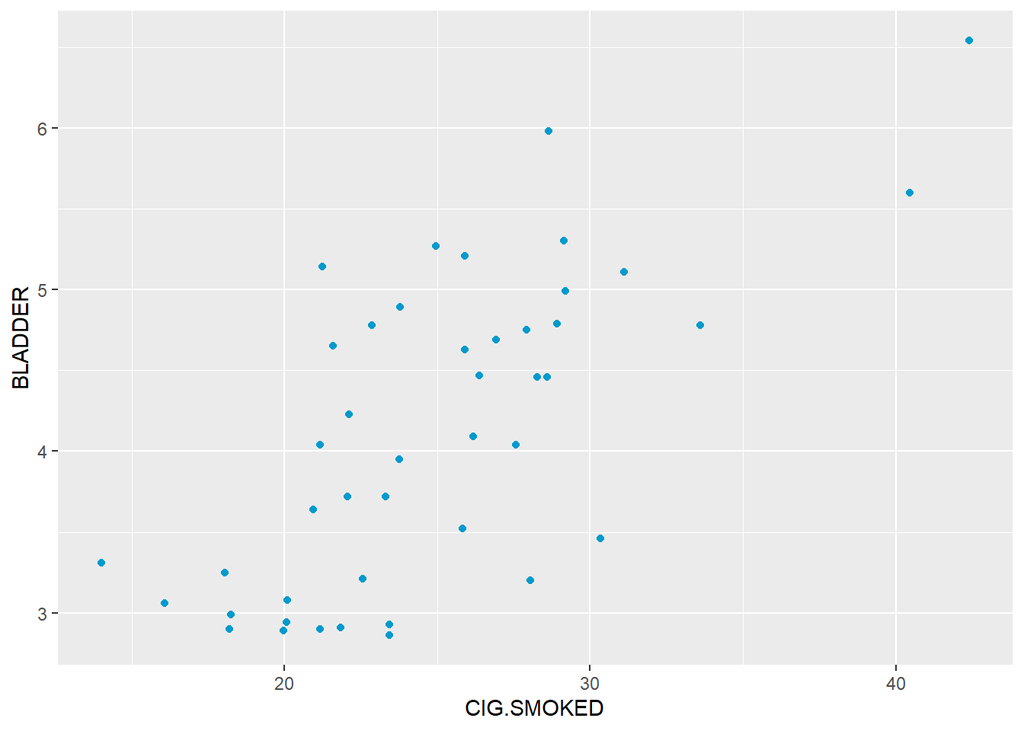

```r
# plot data
library(ggplot2)
ggplot(data = cancer, mapping = aes(x = CIG.SMOKED, y = BLADDER)) +
geom_point(color = "deepskyblue3")
```

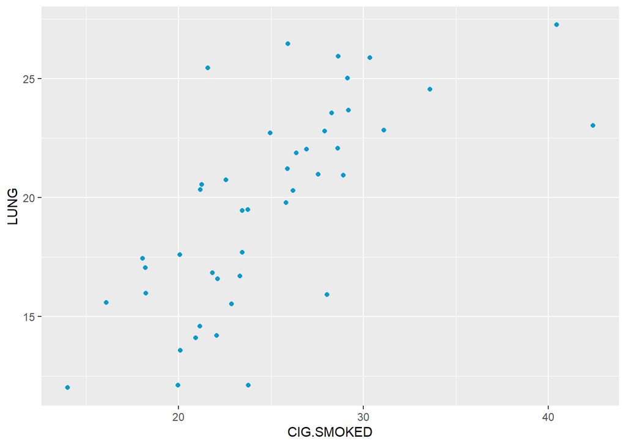

```r
ggplot(data = cancer, mapping = aes(x = CIG.SMOKED, y = LUNG)) +
geom_point(color = "deepskyblue3")
```

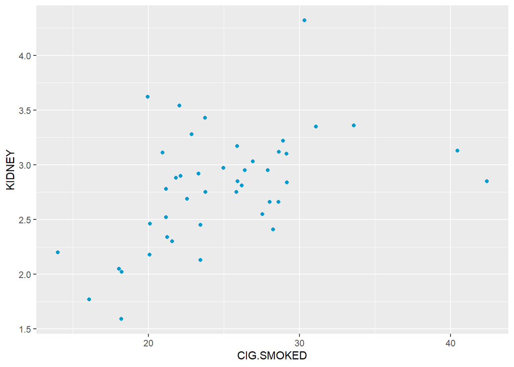

```r
ggplot(data = cancer, mapping = aes(x = CIG.SMOKED, y = KIDNEY)) +
geom_point(color = "deepskyblue3")
```

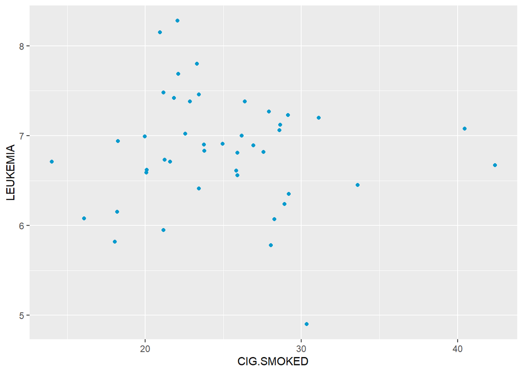

```r
ggplot(data = cancer, mapping = aes(x = CIG.SMOKED, y = LEUKEMIA)) +
geom_point(color = "deepskyblue3")
```

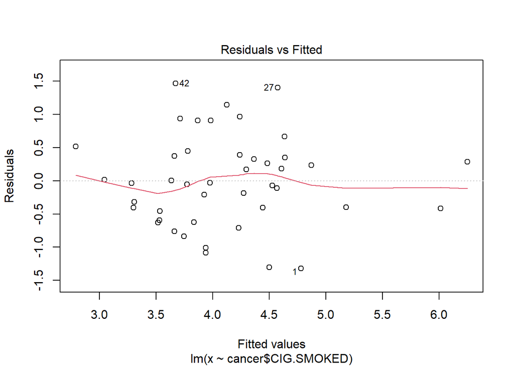

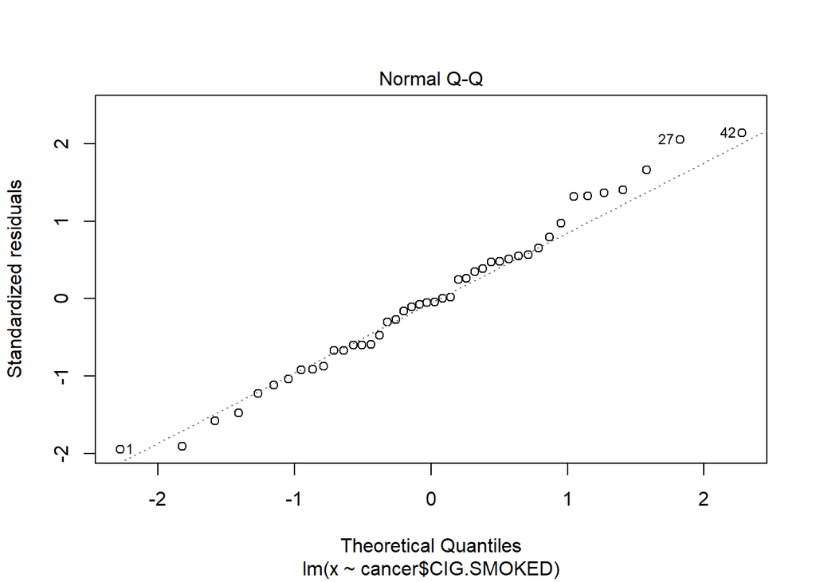

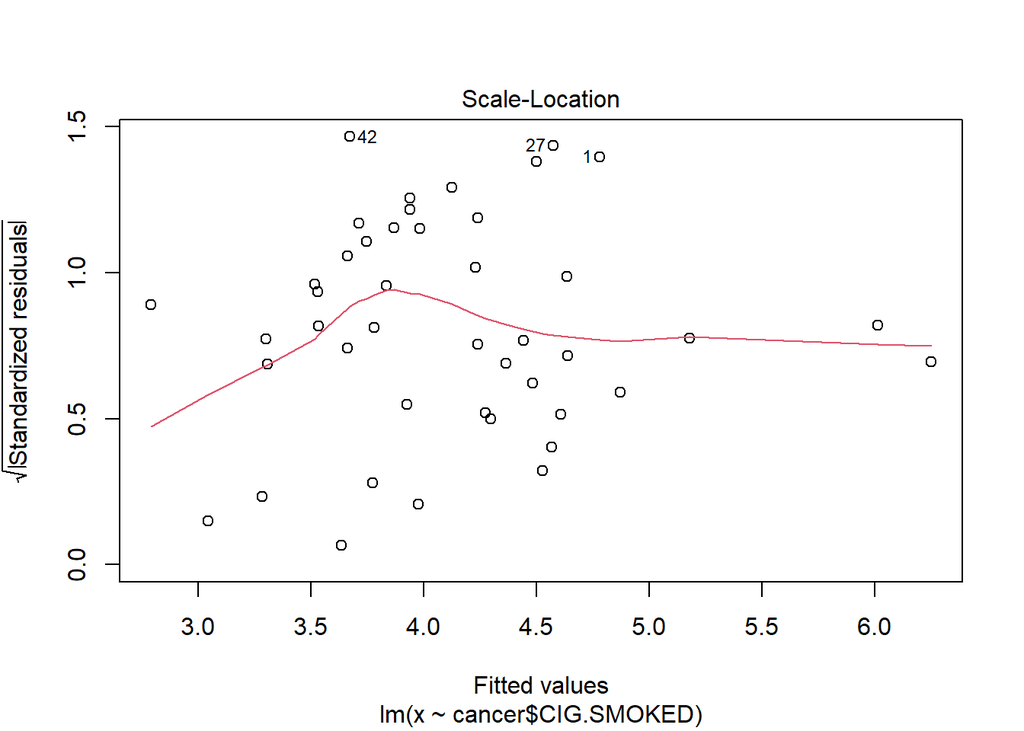

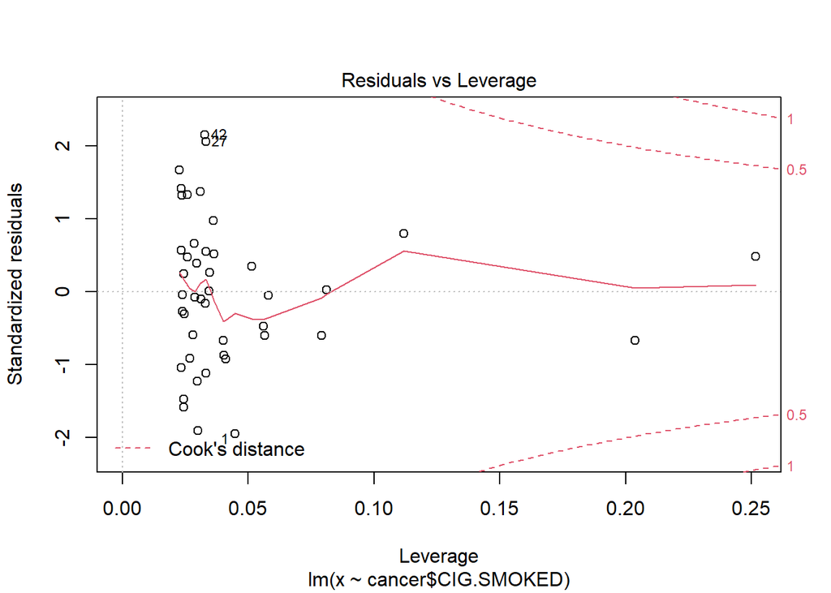

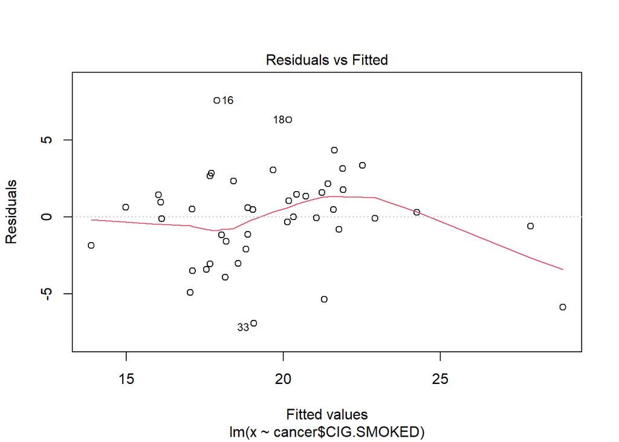

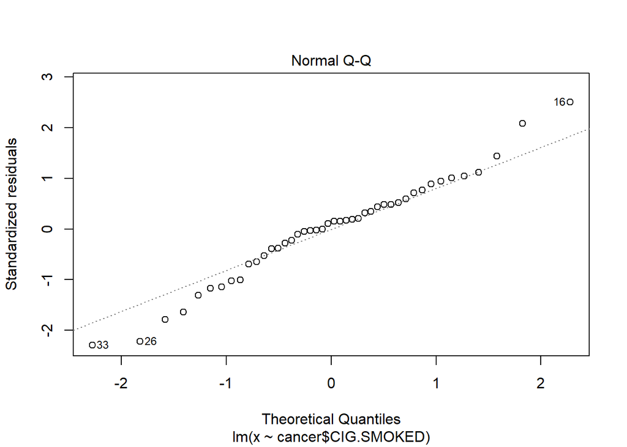

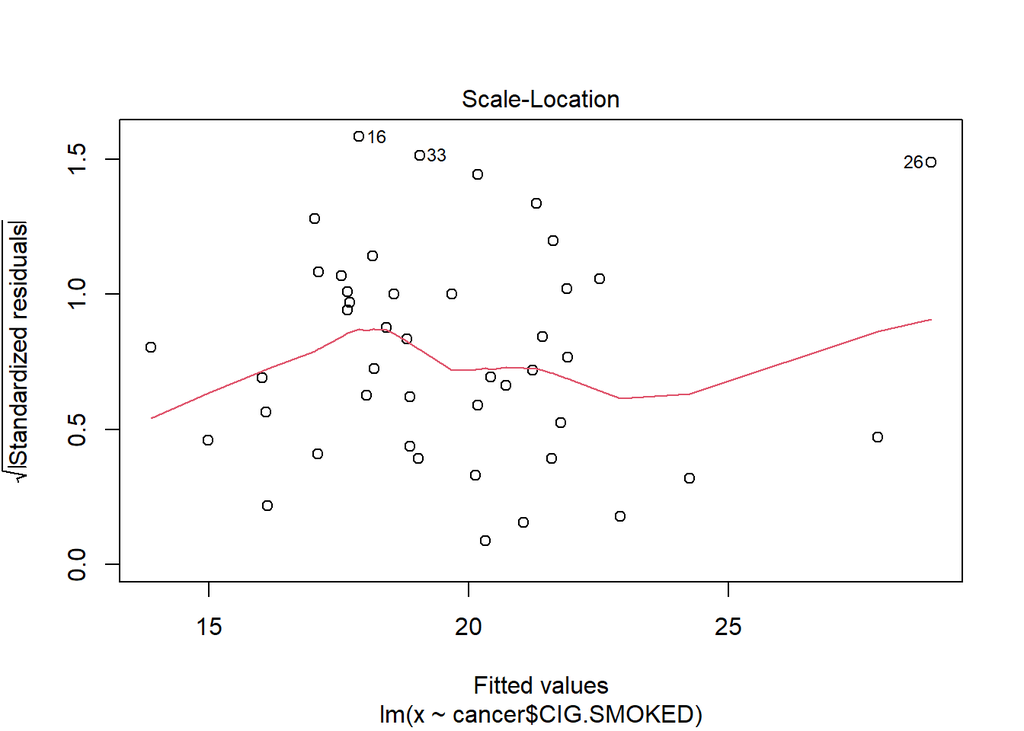

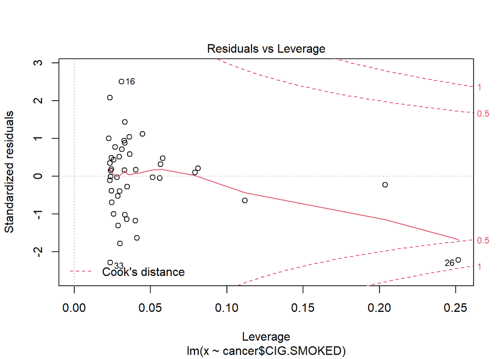

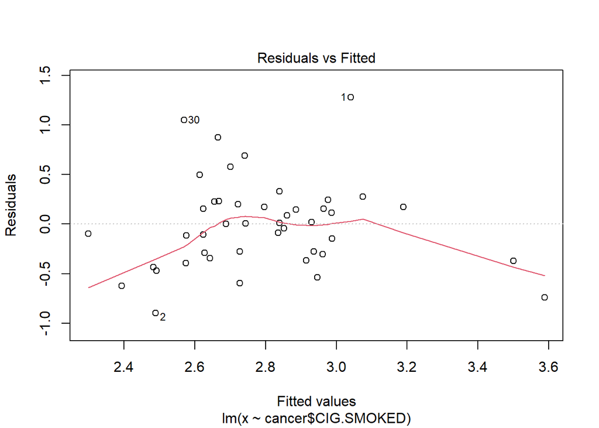

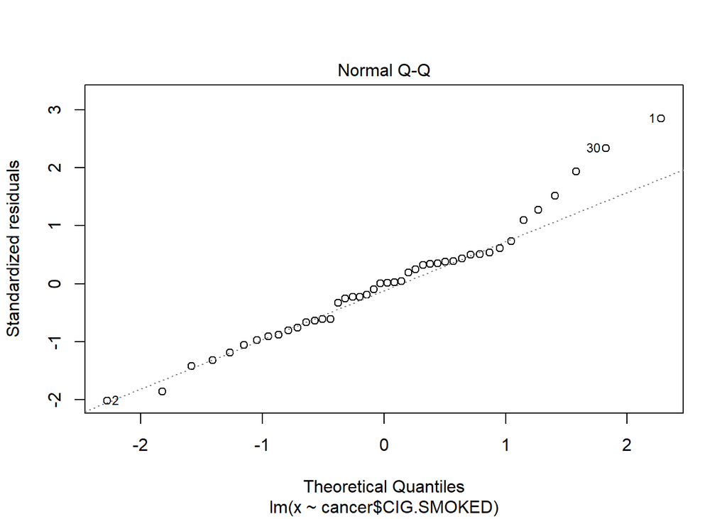

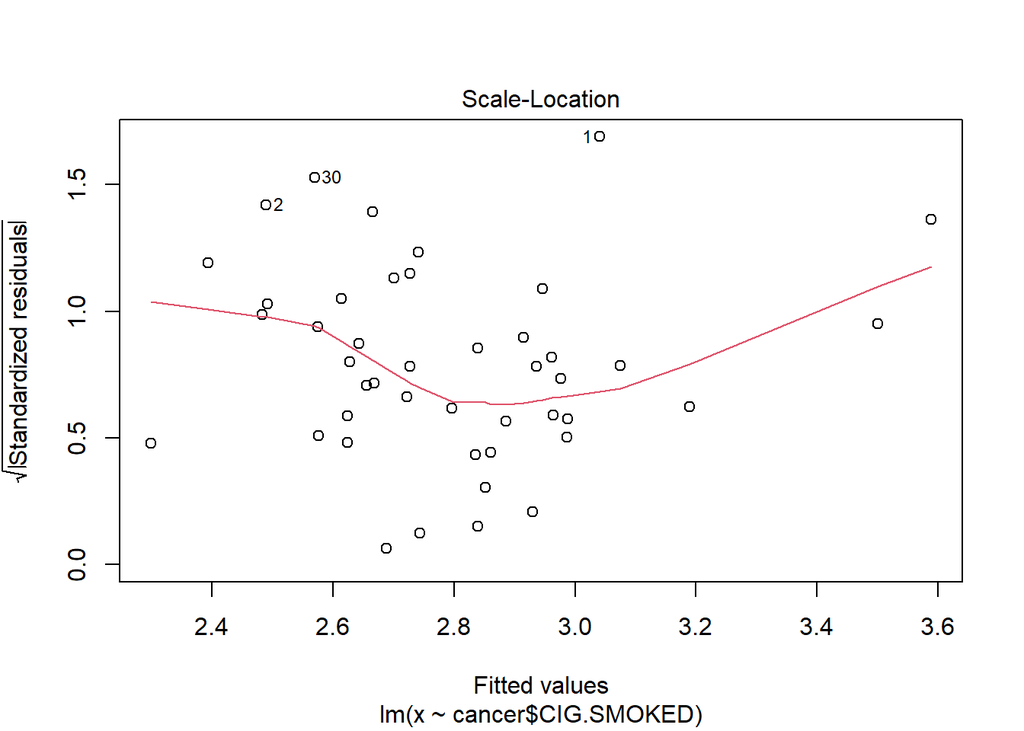

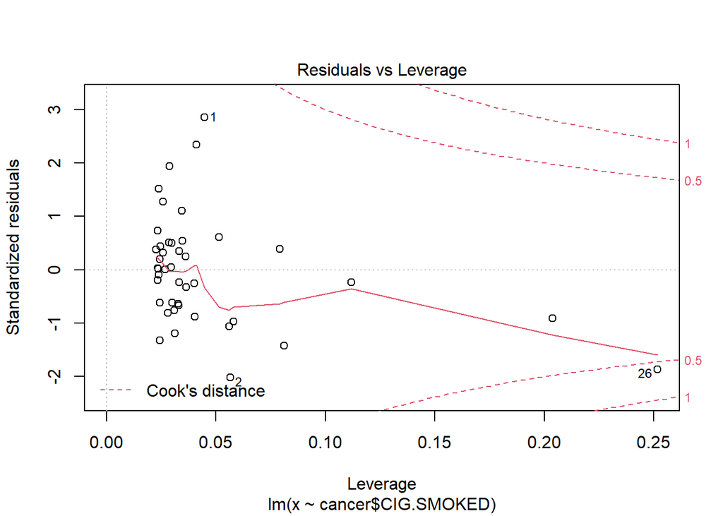

[4 more figures not shown]

```r
# plot LS line data
lapply(cancer[, 3:6], function(x) plot(lm(x~cancer$CIG.SMOKED)))
```

```r
lapply(cancer[, 3:6], function(x) summary(lm(x~cancer$CIG.SMOKED)))
```

```
## $BLADDER
##
## Call:
## lm(formula = x ~ cancer$CIG.SMOKED)
##
## Residuals:
##      Min       1Q   Median       3Q      Max
## -1.32213 -0.42488 -0.03275  0.37872  1.46523
##
## Coefficients:
##                   Estimate Std. Error t value Pr(>|t|)
## (Intercept)        1.08608    0.48437   2.242   0.0303 *
## cancer$CIG.SMOKED  0.12182    0.01898   6.417 9.96e-08 ***
## ---
## Signif. codes:  0 '***' 0.001 '**' 0.01 '*' 0.05 '.' 0.1 ' ' 1
##
## Residual standard error: 0.6938 on 42 degrees of freedom
## Multiple R-squared:  0.4951, Adjusted R-squared:  0.4831
## F-statistic: 41.18 on 1 and 42 DF,  p-value: 9.964e-08
##
##
## $LUNG
##
## Call:
## lm(formula = x ~ cancer$CIG.SMOKED)
##
## Residuals:
##    Min     1Q Median     3Q    Max
## -6.943 -1.656  0.382  1.614  7.561
##
## Coefficients:
##                   Estimate Std. Error t value Pr(>|t|)
## (Intercept)         6.4717     2.1407   3.023  0.00425 **
## cancer$CIG.SMOKED   0.5291     0.0839   6.306 1.44e-07 ***
## ---
## Signif. codes:  0 '***' 0.001 '**' 0.01 '*' 0.05 '.' 0.1 ' ' 1
##
## Residual standard error: 3.066 on 42 degrees of freedom
## Multiple R-squared:  0.4864, Adjusted R-squared:  0.4741
## F-statistic: 39.77 on 1 and 42 DF,  p-value: 1.439e-07
```

[output cut: 27 more lines]

```
##
## Residuals:
##      Min       1Q   Median       3Q      Max
## -1.88722 -0.28618  0.03443  0.42240  1.42784
##
## Coefficients:
##                    Estimate Std. Error t value Pr(>|t|)
## (Intercept)        7.025163   0.449835  15.617   <2e-16 ***
## cancer$CIG.SMOKED -0.007843   0.017630  -0.445    0.659
## ---
## Signif. codes:  0 '***' 0.001 '**' 0.01 '*' 0.05 '.' 0.1 ' ' 1
##
## Residual standard error: 0.6443 on 42 degrees of freedom
## Multiple R-squared:  0.00469,    Adjusted R-squared:  -0.01901
## F-statistic: 0.1979 on 1 and 42 DF,  p-value: 0.6587
```

```r
# identify outliers based on x-value
cancer[cancer$CIG.SMOKED > 40,]
```

```
##    STATE CIG.SMOKED BLADDER  LUNG KIDNEY LEUKEMIA
## 8     DC      40.46    5.60 27.27   3.13     7.08
## 26    NE      42.40    6.54 23.03   2.85     6.67
```

```r
# DC and NE has especially high number of cigarettes smoked. When these two observations are removed, the number of deaths due to bladder, lung, and kidney cancer all appear to be linearly correlated with cigarettes smoked. However, the correlation between the number of deaths due to leukemia and cigarettes smoked seems weak.

# identify outliers based on residual plots
# AK, NJ, and WI in plot bladder; LA, MD, PE in plot lung; AK, Al, ND in plot kidney; AK, MN, SD in plot leukemia.

# looking at the R^2 values and residual plots, linear relationship appears to be stronger in plot_bladder and plot_lung, but it's not apparent in the other two plots. It could be the case that nonlinear(logarithmic) relationships exist in all four plots, if we have bigger x-values for reference.
```

#### 2.11(2) Perform tests on the correlations to see which type of cancer deaths are most significantly correlated with cigarette smoking.

```r
cor(cancer["CIG.SMOKED"], cancer[3:6])
```

```
##              BLADDER      LUNG    KIDNEY    LEUKEMIA
## CIG.SMOKED 0.7036219 0.6974025 0.4873896 -0.06848123
```

```r
cor.test(cancer[["CIG.SMOKED"]], cancer[[3]])
```

```
##
##  Pearson's product-moment correlation
##
## data:  cancer[["CIG.SMOKED"]] and cancer[[3]]
## t = 6.4173, df = 42, p-value = 9.964e-08
## alternative hypothesis: true correlation is not equal to 0
## 95 percent confidence interval:
##  0.5141412 0.8276195
## sample estimates:
##       cor
## 0.7036219
```

```r
cor.test(cancer[["CIG.SMOKED"]], cancer[[4]])
```

```
##
##  Pearson's product-moment correlation
##
## data:  cancer[["CIG.SMOKED"]] and cancer[[4]]
## t = 6.3064, df = 42, p-value = 1.439e-07
## alternative hypothesis: true correlation is not equal to 0
## 95 percent confidence interval:
##  0.5051008 0.8237330
## sample estimates:
##       cor
## 0.6974025
```

```r
cor.test(cancer[["CIG.SMOKED"]], cancer[[5]])
```

```
##
##  Pearson's product-moment correlation
##
## data:  cancer[["CIG.SMOKED"]] and cancer[[5]]
## t = 3.6174, df = 42, p-value = 0.0007922
## alternative hypothesis: true correlation is not equal to 0
## 95 percent confidence interval:
##  0.2227387 0.6851336
## sample estimates:
##       cor
## 0.4873896
```

```r
cor.test(cancer[["CIG.SMOKED"]], cancer[[6]])
```

```
##
##  Pearson's product-moment correlation
##
## data:  cancer[["CIG.SMOKED"]] and cancer[[6]]
## t = -0.44485, df = 42, p-value = 0.6587
## alternative hypothesis: true correlation is not equal to 0
## 95 percent confidence interval:
##  -0.3580815  0.2331390
## sample estimates:
##         cor
## -0.06848123
```

```r
# The t values for the correlation between cigarettes smoked and bladder, lung, kidney, and leukemia cancers are 6.42, 6.31, 3.62, and -0.44 respectively.

# Bladder and lung cancers are most significantly correlated with cigarette smoking, with both correlation coefficients around 0.7 and p-values significantly lower than 0.05. Kidney cancer is mildly correlated with cigarette smoking, with r = 0.49 and p-value < 0.05. In the case of leukemia cancer, we fail to reject the null hypothesis that there is no correlation between leukemia cancer and cigarette smoking.
```